# Générateur d'indices pour CodeNames

## Introduction

**CodeNames** est un jeu de plateau se jouant en 2 équipes de 2 joueurs minimum.

But : Dans chaque équipe, un espion doit faire deviner à son équipe une liste de mots (appelés Nom de Code) inscrit sur une « carte clé » commune aux deux espions.

L’équipe qui trouve tous les noms de Code inscrits sur la carte Clé gagne la partie (l’équipe qui commence doit faire deviner 9 mots et l’autre équipe 8).

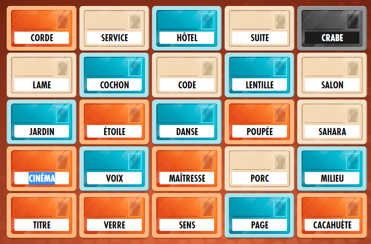

**Déroulement :**

L'équipe avec le plus de cartes à deviner commence, ici ce sont les rouges.

Les équipes sont composées d'agents et d'espions, dans le cas où il n'y a que 4 joueurs dans la partie, il y aura donc 1 agent et 1 espion dans chaque équipe.

L'agent voit les cartes mais ne voit pas leur couleur.

L'espion donne un indice suivi d'un chiffre qui va permettre à son agent de deviner les cartes clés associées. Le chiffre lui permet de savoir combien de cartes sont associées au mot donné.

Par exemple l'espion Rouge pourrait proposer **FILM 2** pour faire deviner les mots **CINEMA** et **TITRE**.

Si l'agent découvre une carte alliée (Rouge dans ce cas), il peut continuer à découvrir d'autres cartes jusqu'à un total du nombre d'indice +1. Dans le cas de **FILM 2** l'agent pourrait découvrir jusqu'à 3 cartes.

Si l'agent découvre une carte adverse (Bleue dans ce cas) ou une carte blanche, il finit son tour, l'espion adverse peut proposer un indice.

Si l'agent découvre la carte assassin (carte noire), la partie est perdu, les adversaires gagnent.

## Création de la grille de mots

On récupère dans un premier temps la liste de tous les mots contenus dans Codenames

```python
file = open("codenames.txt", encoding='utf8').readlines()
words = ([s.replace('\n', '') for s in file])
print(words)
```

```
['Afrique', 'Aiguille', 'Aile', 'Air', 'Alien', 'Allemagne', 'Alpes', 'Amour', 'Ampoule', 'Amérique', 'Ange', 'Angleterre', 'Anneau', 'Appareil', 'Araignée', 'Arc', 'Argent', 'Asile', 'Astérix', 'Atlantique', 'Atout', 'Australie', 'Avion', 'Avocat', 'Baguette', 'Baie', 'Balance', 'Baleine', 'Balle',…
```

Ensuite on va pouvoir générer notre liste de mots

```python
import random

# Mélange de la liste
random.shuffle(words)
words = words[:25]
# Tous les morts mis en minuscule
words = list(map(str.lower,words))
```

Maintenant on va assigner une couleur à chaque mot

```python
red_words = words[:9]
blue_words = words[9:17]
white_words = words[17:24]
black_words = words[24:25]

print("les mots rouges sont : ",red_words)
print("les mots bleus sont : ",blue_words)
print("les mots blancs sont : ",white_words)
print("le mot noir est : ",black_words)
```

```
les mots rouges sont :  ['histoire', 'molière', 'pouce', 'garde', 'mineur', 'laser', 'ninja', 'campagne', 'pôle']
les mots bleus sont :  ['neige', 'ampoule', 'mort', 'chien', 'avocat', 'pomme', 'école', 'bar']
les mots blancs sont :  ['tokyo', 'reine', 'pendule', 'gauche', 'voleur', 'mode', 'jungle']
le mot noir est :  ['tambour']
```

On peut ensuite créer le plateau de jeu à partir des mots assignés

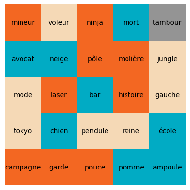

```python
import numpy as np
import matplotlib.pyplot as plt

# Création de la grille
grid = np.random.randint(4, size=(5, 5))

# Création du graphique
fig, ax = plt.subplots()

random.shuffle(words)

n=0
# Dessin des rectangles et ajout des labels
for i in range(len(grid)):
    for j in range(len(grid[i])):
        if words[n] in red_words:
            color = "#f36722"
        elif words[n] in blue_words:
            color = "#01abc4"
        elif words[n] in white_words:
            color = "#f5d9b6"
        else :
            color = "#949494"
        rect = plt.Rectangle((j, i), 1, 1, facecolor=color)
        ax.add_patch(rect)
        ax.text(j + 0.5, i + 0.5, words[n], ha='center', va='center')
        n=n+1

# Configuration du graphique
ax.set_xlim([0, 5])
ax.set_ylim([0, 5])
ax.set_aspect('equal')
ax.axis('off')

# Affichage de la grille
plt.show()
```

Voilà, on peut à présent générer nos propres grilles de codenames, celà va nous être utile pour faire des test randomisés et mieux observer nos IA.

## Développement de l'IA

Pour notre IA nous utiliserons gensim avec un modèle pré entrainé sur la langue francaise. Il est possible d'adapter le jeu dans n'importe quelle langue tant que nous avons une liste de mots disponible et un modèle pré entrainé disponible également.

Le modèle utilisé est disponible ici : https://fauconnier.github.io/#data

```python
from gensim.models import KeyedVectors

# Chemin vers le modèle Word2Vec pré-entraîné
path = "frWac_no_postag_no_phrase_500_cbow_cut100.bin"

# Charger le modèle
model = KeyedVectors.load_word2vec_format(path, binary=True)

# Trouver les 10 mots les plus similaires pour la liste de mots donnée
similar_words = model.most_similar(positive=red_words,negative=blue_words+white_words+black_words, topn=10)

# Afficher les résultats
for word, similarity in similar_words:
    print(word, similarity)
```

```
notamment 0.46054667234420776
projet 0.43221139907836914
concerner 0.4272434711456299
développement 0.40144985914230347
mise 0.3983055651187897
de 0.39675766229629517
élaboration 0.39608973264694214
communication 0.39589524269104004
information 0.39216530323028564
objectif 0.3897892236709595
```

L'IA nous permet de récupérer les 10 premiers mots qui sont les plus proches avec tout ceux que l'on a à découvrir.

Cette méthode n'est pas forcément la meilleure, les mots sont un peu trop hasardeux et on perd en précision.

On ne peut pas demander à quelqu'un de trouver 8 ou 9 mots d'un coup en un seul indice.

On va chercher une autre méthode

Au début du projet nous avions cette fonction qui nous permettait d'avoir une liste d'indice mais rien de très pertinent, essayons avec notre nouvelle méthode.

### Méthode 1

La méthode la plus basique consiste à demander au modèle de trouver le mot le plus similaire au mot à faire deviner. On regarde ce que ça donne avec les mots de l'équipe rouge.

```python
similar_words = []

for word in red_words:
    result = model.most_similar(word)
    similar_words.append([word, result[0]])

similar_words
```

```
[['histoire', ('historien', 0.6288945078849792)],
 ['molière', ('tartuffe', 0.5854926705360413)],
 ['pouce', ('wxga', 0.4157608449459076)],
 ['garde', ('gardes', 0.663730263710022)],
 ['mineur', ('parental', 0.5457035899162292)],
 ['laser', ('femtosecond', 0.628848671913147)],
 ['ninja', ('konoha', 0.6826215982437134)],
 ['campagne', ('présidentiel', 0.6299965977668762)],
 ['pôle', ('pôles', 0.5908185243606567)]]
```

On remarque que les résultats sont plutôt fiables, avec un score de similarité supérieur à 40%.

**Conclusion :** - Avantage de cette méthode : le mot trouvé pour chaque mot est fiable - Inconvénients de cette méthode : le joueur ne peut générer une réponse que pour faire deviner un seul mot ce qui est désavantageux pour gagner la partie. De plus les mots des cartes autres que les cartes rouges ne sont pas prises en compte donc l'algorithme peut générer un mot similaire à ceux des cartes bleues, blanches et noire.

### Méthode 2

Pour la méthode suivante on peut cette fois prendre en compte les mots des cartes à ne pas faire deviner.

```python
similar_words = []

for word in red_words:
    result = model.most_similar(positive=word, negative=blue_words + white_words + black_words)
    similar_words.append([word, result[0]])

similar_words
```

```
[['histoire', ('notamment', 0.43203893303871155)],
 ['molière', ('concerner', 0.44410112500190735)],
 ['pouce', ('concerner', 0.4504103362560272)],
 ['garde', ('concerner', 0.48735135793685913)],
 ['mineur', ('concerner', 0.5174863934516907)],
 ['laser', ('concerner', 0.46216514706611633)],
 ['ninja', ('concerner', 0.45820024609565735)],
 ['campagne', ('notamment', 0.4774458408355713)],
 ['pôle', ('notamment', 0.49842166900634766)]]
```

On marque cette fois que les mots ne sont plus très similaires aux mots à faire deviner. On réessaye cette fois sans les mots blancs.

```python
similar_words = []

for word in red_words:
    result = model.most_similar(positive=word, negative=blue_words + black_words)
    similar_words.append([word, result[0]])

similar_words
```

```
[['histoire', ('historique', 0.42729300260543823)],
 ['molière', ('contexte', 0.36368998885154724)],
 ['pouce', ('global', 0.36651721596717834)],
 ['garde', ('notamment', 0.39622434973716736)],
 ['mineur', ('notamment', 0.4286862015724182)],
 ['laser', ('analyse', 0.40131038427352905)],
 ['ninja', ('stratégie', 0.3578333854675293)],
 ['campagne', ('politique', 0.4304974675178528)],
 ['pôle', ('développement', 0.47816339135169983)]]
```

Les résultats sont légèrement supérieurs. On réessaye sans les mots bleus.

```python
similar_words = []

for word in red_words:
    result = model.most_similar(positive=word, negative=black_words)
    similar_words.append([word, result[0]])

similar_words
```

```
[['histoire', ('historien', 0.4882574677467346)],
 ['molière', ('tartuffe', 0.3958415687084198)],
 ['pouce', ('belinea', 0.3089474141597748)],
 ['garde', ('gardes', 0.3980405330657959)],
 ['mineur', ('parental', 0.45970654487609863)],
 ['laser', ('femtoseconde', 0.45917126536369324)],
 ['ninja', ('konoha', 0.46734681725502014)],
 ['campagne', ('présidentiel', 0.46830251812934875)],
 ['pôle', ('synergie', 0.45448851585388184)]]
```

```python
black_words
```

```
['tambour']
```

Les résultats sont similaires à ceux de la méthode 1.  
**Conclusion :** On a les mêmes résultats qu'avec la méthode 1 tout en faisant en sorte d'avoir des réponse les moins similaires possibles au mot noir.

### Méthode 3

On peut utiliser la dernière technique en essayant cette fois de faire deviner 2 mots. On établit d'abord les similarités pour chaque paire de mots de l'équipe rouge.

```python
similarity_scores = []
for i in red_words:
    for j in red_words:
        if i != j:
            similarity = model.similarity(i, j)
            # Vérifie que la version inversée de la paire n'a pas déjà été ajoutée
            if [similarity, j, i] not in similarity_scores:
                similarity_scores.append([similarity, i, j])

# Trie la liste par le score dans l'ordre décroissant
similarity_scores = sorted(similarity_scores, key=lambda x: x[0], reverse=True)
similarity_scores[:10]
```

```
[[0.29597896, 'garde', 'mineur'],
 [0.17042105, 'histoire', 'molière'],
 [0.110416755, 'pouce', 'laser'],
 [0.09971334, 'laser', 'pôle'],
 [0.091183074, 'pouce', 'ninja'],
 [0.04736238, 'garde', 'campagne'],
 [0.035070244, 'laser', 'ninja'],
 [0.027356967, 'molière', 'garde'],
 [0.021405002, 'pouce', 'garde'],
 [0.019660559, 'garde', 'ninja']]
```

On peut ensuite définir en seuil (disons 15%) au-dessus duquel on part de principe qu'il est possible de trouver un mot associé et filtrer les paires selon ce seuil.

```python
filtered_scores = []

for similarity_score in similarity_scores:
  if similarity_score[0] >= 0.15:
    filtered_scores.append(similarity_score)

similarity_scores = filtered_scores

# Enlève les mots présents plusieurs fois qui ont un score moins élevé s'il y en a
for item in similarity_scores:
  better_word1 = item[1]
  better_word2 = item[2]
  for index, item2 in enumerate(similarity_scores):
    word1 = item2[1]
    word2 = item2[2]
    if item != item2 and (better_word1 == word1 or better_word2 == word2 or better_word1 == word2 or better_word2 == word1):
      similarity_scores.pop(index)

similarity_scores
```

```
[[0.29597896, 'garde', 'mineur'], [0.17042105, 'histoire', 'molière']]
```

Finalement on peut deviner tous les mots de l'équipe rouge.

```python
guessed_words = []

print("Mots de l'équipe rouge : ")

# Paires retenues
for pair in similarity_scores:
  result = model.most_similar(positive=[pair[1], pair[2]], negative=black_words)[0]
  print(f"Mot '{result[0]}' trouvé pour '{pair[1]}' et '{pair[2]}'.")

  guessed_words.append(pair[1])
  guessed_words.append(pair[2])

# Mots restants que l'on fait deviner 1 par 1
for word in red_words:
  if word not in guessed_words:
    result = model.most_similar(positive=word, negative=black_words)[0]
    print(f"Mot '{result[0]}' trouvé pour '{word}'.")
```

```
Mots de l'équipe rouge :
Mot 'parental' trouvé pour 'garde' et 'mineur'.
Mot 'littérature' trouvé pour 'histoire' et 'molière'.
Mot 'belinea' trouvé pour 'pouce'.
Mot 'femtoseconde' trouvé pour 'laser'.
Mot 'konoha' trouvé pour 'ninja'.
Mot 'présidentiel' trouvé pour 'campagne'.
Mot 'synergie' trouvé pour 'pôle'.
```

On tente la même chose cette fois en rajoutant les mots blancs et bleus dans la partie négative.

```python
guessed_words = []

print("Mots de l'équipe rouge : ")

# Paires retenues
for pair in similarity_scores:
  result = model.most_similar(positive=[pair[1], pair[2]], negative=black_words + white_words + blue_words)[0]
  print(f"Mot '{result[0]}' trouvé pour '{pair[1]}' et '{pair[2]}'.")

  guessed_words.append(pair[1])
  guessed_words.append(pair[2])

# Mots restants que l'on fait deviner 1 par 1
for word in red_words:
  if word not in guessed_words:
    result = model.most_similar(positive=word, negative=black_words)[0]
    print(f"Mot '{result[0]}' trouvé pour '{word}'.")
```

```
Mots de l'équipe rouge :
Mot 'concerner' trouvé pour 'garde' et 'mineur'.
Mot 'notamment' trouvé pour 'histoire' et 'molière'.
Mot 'belinea' trouvé pour 'pouce'.
Mot 'femtoseconde' trouvé pour 'laser'.
Mot 'konoha' trouvé pour 'ninja'.
Mot 'présidentiel' trouvé pour 'campagne'.
Mot 'synergie' trouvé pour 'pôle'.
```